# Inspiration Corner

2025-10-17

## Writer’s block? Here’s the solution:

- This is an app that will help you on making progress when stuck trying to bring your next novel, all you have to do:
- The app will keep bringing up new words as you continue to write
- This will jog your memory and stimuate the thinking process!

## Instructions

- Click in the link to get to the app -> https://paco23ch.shinyapps.io/textPrediction/
- Once the page loads, follow the instructions to load the pre-trained model
- Once the file has been loaded, all you have to do is to select the settings for the model:
  - How many words to use to predict the next word
  - How many additional suggestions you want generated

## Algorithm

- The pre-trained model contains 4 main sets to be used (1-4 grams):
- Based on the settings, the model will use the highest preferred value to predict the next word
  - for example n-gram=4, means the model will first try to predict with the last 3 words typed in to find a suggestion
  - if no suggestions can be found, the max n-gram value will be decreased by 1 to find more options
  - if nothing can be found, then the most popular words will be used as suggestions
- The model will return the most likely word based on the probability calculated previously and the k number of values requested by the user, along with their probability

## n-gram Test results

- Sampled data to see the effect on accuracy

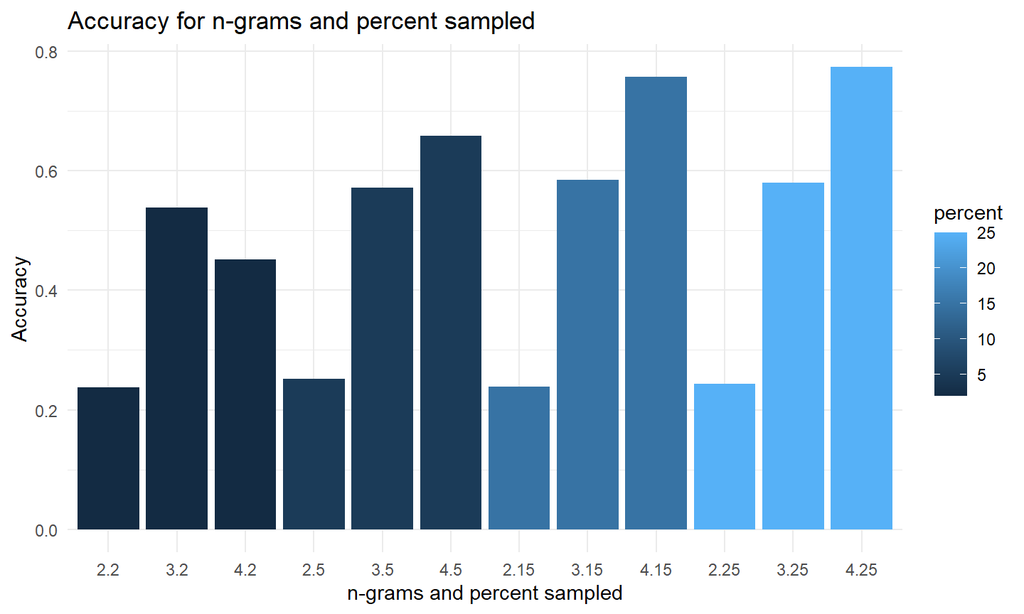